# Assignment 3 - NMS2

Samantha Stephens,Metlha Ganelang,Stephen Bottrell, Nathan Colvin

20 April 2018

## Missing value summary

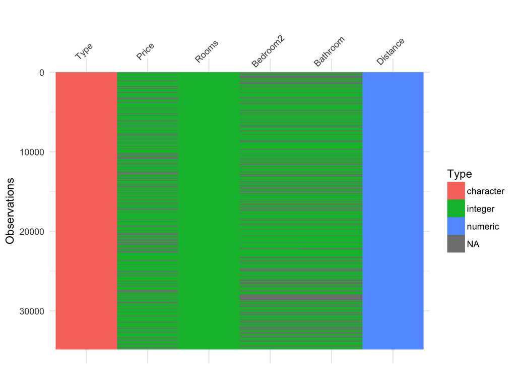

```r
houses2 <- houses %>%
  select(Price, Rooms, Type, Distance, Bedroom2, Bathroom)
vis_dat(houses2)
```

```r
miss_summary(houses2)
```

```
## # A tibble: 1 x 7
##   miss_df_prop miss_var_prop miss_case_prop miss_case_table miss_var_table
##          <dbl>         <dbl>          <dbl> <list>          <list>
## 1        0.115         0.667          0.403 <tibble [4 × 3… <tibble [5 × …
## # ... with 2 more variables: miss_var_summary <list>,
## #   miss_case_summary <list>
```

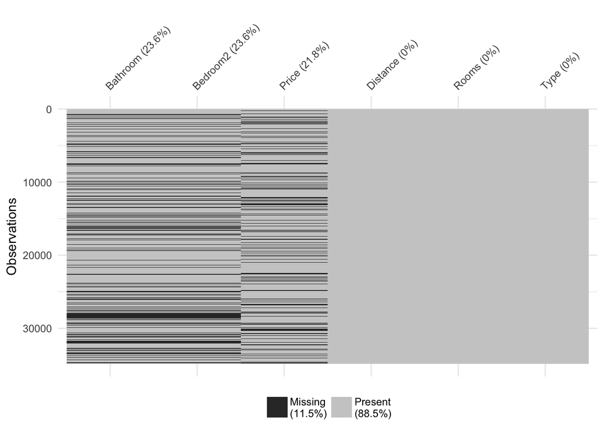

```r
vis_miss(houses2,sort_miss = TRUE)
```

## Missing Values Strategy

#### It can be seen from these summaries that there are only missing values for three variables: the price of a property (Price), the number of bathrooms it has (Bathroom) and the number of bedrooms it has (Bedroom2). Each of these three variables has just over 20% of values missing, which is a significant amount. Given the model will have Price as the response variable, observations with a missing value for Price should be excluded (which R automatically does). For the potential explanatory variables Bathroom and Bedroom2, one approach to ‘fill in’ the missing values is to use the mean for these numerical variables rounded to the nearest positive integer. However, this would cause there to be a lot of observations with the same value for these variables. A better option might be to find the rounded average of each of these variables for every suburb and use those values for every missing value for observations in those suburbs. If there is a suburb with all missing values, the rounded average of the entire variable could be used. However, this approach could potentially be complicated and time-consuming, especially if it has to be done for each suburb individually. The summaries of missing values above indicate that at least the majority of properties with a missing value for Bathroom also have a missing value for Bedroom2 (possibly all). For these observations, this is missing values for 1/3 of the variables we are considering for some role in the model, a significant proportion. As this is the case, it might just be best to leave out these observations (automatically done by R), even though there are many of them.

```r
houses2 <- houses2 %>% filter(!is.na(Price))
```

## plots summarising relationship between price

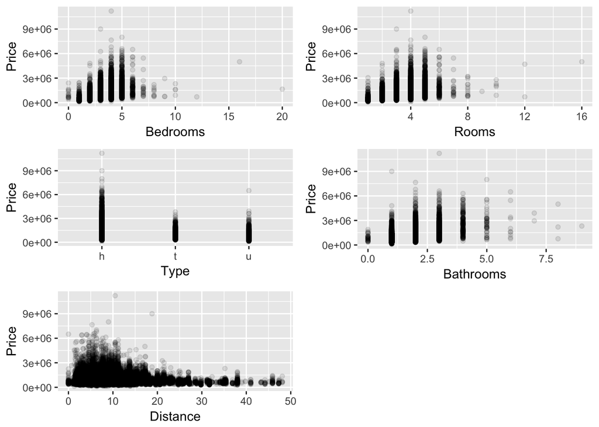

```r
p1<- ggplot(houses2, aes(x=Bedroom2, y=Price)) +
  geom_point(alpha=0.1) +
  scale_colour_brewer("", palette="Dark2") +
  theme(legend.position="bottom") +
  xlab('Bedrooms') +
  ylab("Price")
p2 <- ggplot(houses2, aes(x=Rooms, y=Price)) +
  geom_point(alpha=0.1) +
  scale_colour_brewer("", palette="Dark2") +
  theme(legend.position="bottom") +
  xlab('Rooms') +
  ylab("Price")
p3 <- ggplot(houses2, aes(x=Type, y=Price)) +
  geom_point(alpha=0.1) +
  scale_colour_brewer("", palette="Dark2") +
  theme(legend.position="bottom") +
  xlab('Type') +
  ylab("Price")
p4 <- ggplot(houses2, aes(x=Bathroom, y=Price)) +
  geom_point(alpha=0.1) +
  scale_colour_brewer("", palette="Dark2") +
  theme(legend.position="bottom") +
  xlab('Bathrooms') +
  ylab("Price")
p5 <- ggplot(houses2, aes(x=Distance, y=Price)) +
  geom_point(alpha=0.1) +
  scale_colour_brewer("", palette="Dark2") +
  theme(legend.position="bottom") +
  xlab('Distance') +
  ylab("Price")
grid.arrange(p1, p2, p3, p4, p5, ncol=2)
```

## Summary Plot Explanations

#### The Price-Distance scatterplot suggests that properties with high prices are most likely to be within 15 km of the Melbourne CBD compared to further away. The range most property prices are in generally increases as the number of bedrooms and bathrooms (and total rooms) increase. However, while there are more highly-priced properties when there is a higher number of rooms, there are still many at lower prices. This is likely due in part to higher distances from the CBD helping lower prices. As the number of bedrooms, bathrooms and rooms increases even further, property prices mostly are at lower levels than before, however there is not as much data for these properties. There is a range of prices for all property types (houses, townhouses and units), however it is more common for houses to be among the highest half of prices than the other types according to the Price-Type scatterplot. Because there are a lot of data points, there is a lot of black in the scatterplots, which makes it more difficult to definitively draw conclusions from these graphs.

## build model:

### Model 1

```r
houses3 <- houses2 %>% filter(Rooms < 10)

summarise(houses2 %>% group_by(Rooms), ave = mean(Price), count = n())
```

```
## # A tibble: 12 x 3
##    Rooms      ave count
##    <int>    <dbl> <int>
##  1     1  432889.  1196
##  2     2  759484.  6787
##  3     3 1028500. 11957
##  4     4 1369597.  5918
##  5     5 1818862.  1209
##  6     6 1882613.   137
##  7     7 1791675.    20
##  8     8 1716858.    14
##  9     9 1380000.     1
## 10    10 2018000.     5
## 11    12 2705000.     2
## 12    16 5000000.     1
```

```r
mod1 <- lm(Price~Rooms+Type+Distance+Bedroom2+Bathroom, data=houses2)
tidy(mod1)
```

```
##          term   estimate  std.error  statistic       p.value
## 1 (Intercept)  652067.34 15351.7547  42.475101  0.000000e+00
## 2       Rooms  168344.31 13127.5205  12.823771  1.674293e-37
## 3       Typet -304850.36 13552.1086 -22.494681 9.796801e-111
## 4       Typeu -407348.31 11106.4038 -36.676886 2.021893e-285
## 5    Distance  -38669.85   526.0495 -73.509910  0.000000e+00
## 6    Bedroom2   12819.71 12806.4020   1.001039  3.168197e-01
## 7    Bathroom  260776.19  6377.9053  40.887436  0.000000e+00
```

```r
glance(mod1)
```

```
##   r.squared adj.r.squared    sigma statistic p.value df    logLik      AIC
## 1 0.4184069     0.4182391 497769.5  2493.134       0  7 -302362.6 604741.2
##        BIC     deviance df.residual
## 1 604804.7 5.151974e+15       20793
```

```r
confint_tidy(mod1)
```

```
##     conf.low  conf.high
## 1  621976.70  682157.98
## 2  142613.35  194075.28
## 3 -331413.55 -278287.17
## 4 -429117.73 -385578.89
## 5  -39700.95  -37638.75
## 6  -12281.84   37921.25
## 7  248275.00  273277.39
```

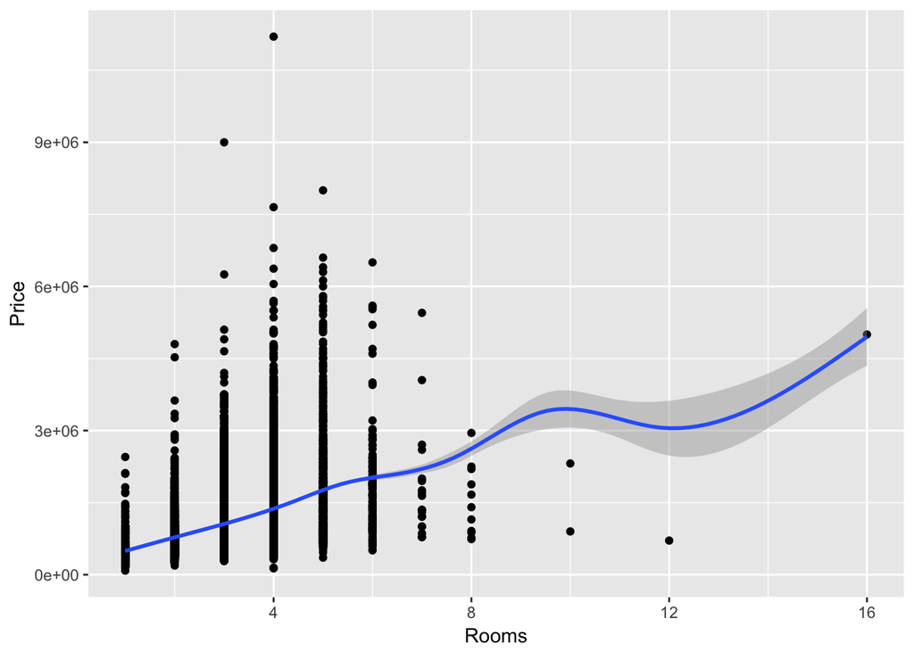

```r
mod1_fit <-augment(mod1,houses2)
p1<- ggplot(mod1_fit, aes(x=.fitted, y=.std.resid)) +
  geom_point()

ggplot(mod1_fit) + geom_point(aes(x = Rooms, y = Price)) + geom_smooth(aes(x = Rooms, y =.fitted))
```

### Model 2

```r
mod2 <- lm(Price~Rooms+I(Rooms^2)+Type+Distance+I(Distance^2)+Bathroom, data=houses2)
tidy(mod2)
```

```
##            term     estimate   std.error  statistic       p.value
## 1   (Intercept)  655408.2139 26527.20049  24.707025 7.388281e-133
## 2         Rooms  283233.6336 14097.96280  20.090394  6.252937e-89
## 3    I(Rooms^2)  -12591.7929  1888.37890  -6.668044  2.657436e-11
## 4         Typet -292698.0150 13408.21426 -21.829754 1.802917e-104
## 5         Typeu -393965.1837 11490.66616 -34.285670 1.188591e-250
## 6      Distance  -68516.7263  1492.38110 -45.911012  0.000000e+00
## 7 I(Distance^2)     875.6474    41.35209  21.175406  1.763961e-98
## 8      Bathroom  257475.7473  6299.59146  40.871817  0.000000e+00
```

```r
glance(mod2)
```

```
##   r.squared adj.r.squared  sigma statistic p.value df    logLik      AIC
## 1 0.4314155      0.431224 492183  2253.714       0  8 -302127.3 604272.6
##        BIC     deviance df.residual
## 1 604344.1 5.036739e+15       20792
```

```r
confint_tidy(mod2)
```

```
##      conf.low    conf.high
## 1  603412.829  707403.5982
## 2  255600.526  310866.7415
## 3  -16293.163   -8890.4228
## 4 -318979.162 -266416.8681
## 5 -416487.787 -371442.5808
## 6  -71441.910  -65591.5428
## 7     794.594     956.7007
## 8  245128.056  269823.4385
```

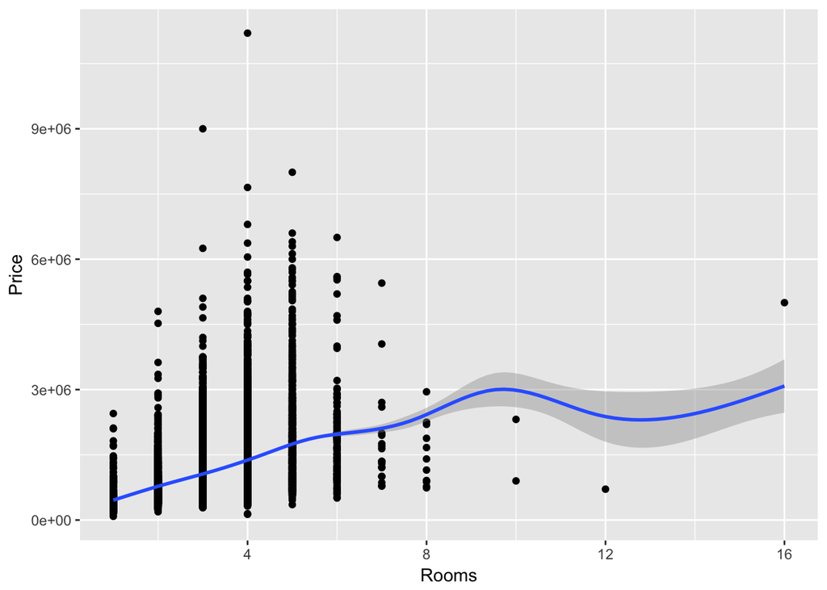

```r
mod2_fit <-augment(mod2,houses2)
p2<- ggplot(mod2_fit, aes(x=.fitted, y=.std.resid)) +
  geom_point()

ggplot(mod2_fit) + geom_point(aes(x = Rooms, y = Price)) + geom_smooth(aes(x = Rooms, y =.fitted))
```

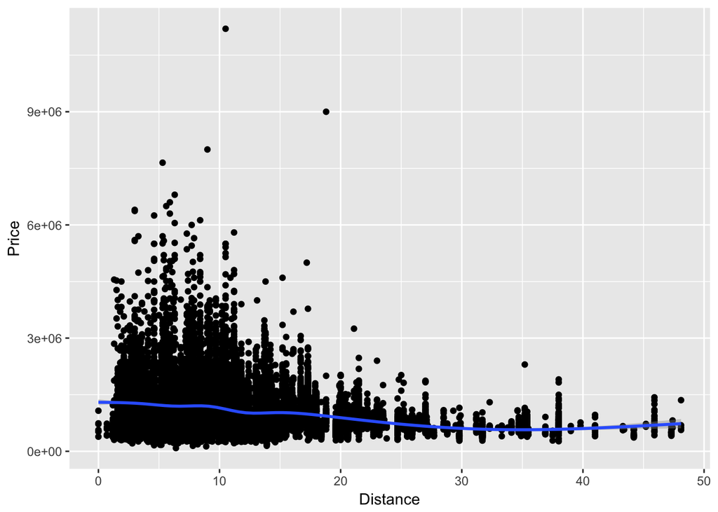

```r
ggplot(mod2_fit) + geom_point(aes(x = Distance, y = Price)) + geom_smooth(aes(x = Distance, y =.fitted))
```

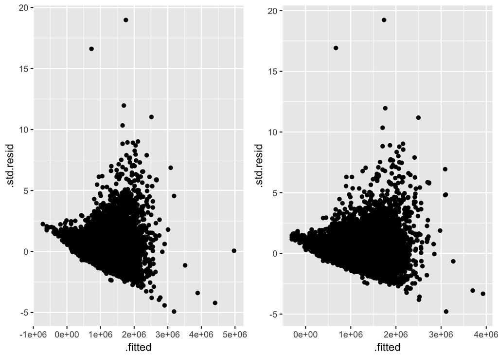

```r
grid.arrange(p1, p2, ncol=2)
```

### Model 3

```r
mod3 <- lm(Price~Rooms*I(Rooms^2)*Type*Distance*I(Distance^2)*Bathroom, data=houses2)
tidy(mod3)
```

```
##                                                      term      estimate
## 1                                             (Intercept) -2.643687e+06
## 2                                                   Rooms  2.738581e+06
## 3                                              I(Rooms^2) -6.221238e+05
## 4                                                   Typet  3.662602e+06
## 5                                                   Typeu -8.460894e+04
## 6                                                Distance  8.179370e+05
## 7                                           I(Distance^2) -4.434153e+04
## 8                                                Bathroom  3.346589e+06
## 9                                        Rooms:I(Rooms^2)  5.377919e+04
## 10                                            Rooms:Typet -2.307958e+06
## 11                                            Rooms:Typeu  6.185481e+06
## 12                                       I(Rooms^2):Typet  1.766104e+05
## 13                                       I(Rooms^2):Typeu -5.132432e+06
## 14                                         Rooms:Distance -6.657089e+05
```

[output cut: 179 more lines]

```r
glance(mod3)
```

```
##   r.squared adj.r.squared    sigma statistic p.value df    logLik      AIC
## 1 0.4982588     0.4959566 463329.5  216.4243       0 96 -300826.6 601847.3
##        BIC     deviance df.residual
## 1 602617.7 4.444615e+15       20704
```

```r
confint_tidy(mod3)
```

```
##         conf.low     conf.high
## 1  -4.394185e+06 -8.931896e+05
## 2   1.257400e+06  4.219763e+06
## 3  -1.044147e+06 -2.001002e+05
## 4  -1.498704e+08  1.571956e+08
## 5  -1.502810e+07  1.485889e+07
## 6   4.396084e+05  1.196265e+06
## 7  -6.899065e+04 -1.969240e+04
## 8   2.056311e+06  4.636867e+06
## 9   1.415802e+04  9.340036e+04
## 10 -1.684131e+08  1.637972e+08
## 11 -1.119329e+07  2.356425e+07
## 12 -5.726422e+07  5.761745e+07
## 13 -1.206246e+07  1.797599e+06
## 14 -9.768020e+05 -3.546158e+05
```

[output cut: 82 more lines]

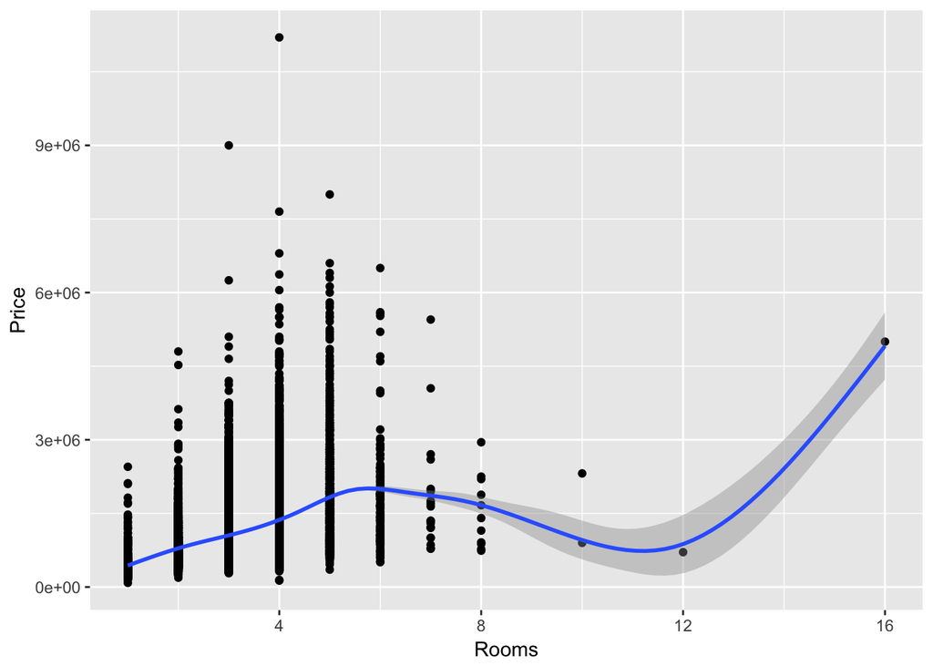

```r
mod3_fit <-augment(mod3,houses2)
p3<- ggplot(mod3_fit, aes(x=.fitted, y=.std.resid)) +
  geom_point()

ggplot(mod3_fit) + geom_point(aes(x = Rooms, y = Price)) + geom_smooth(aes(x = Rooms, y =.fitted))
```

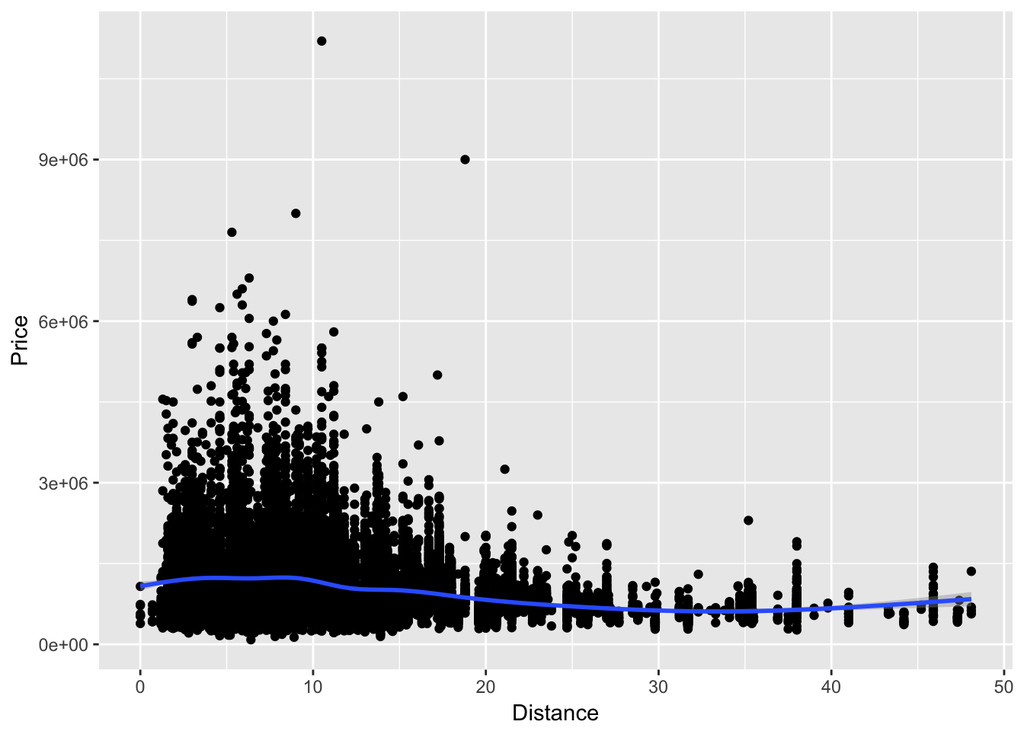

```r
ggplot(mod3_fit) + geom_point(aes(x = Distance, y = Price)) + geom_smooth(aes(x = Distance, y =.fitted))
```

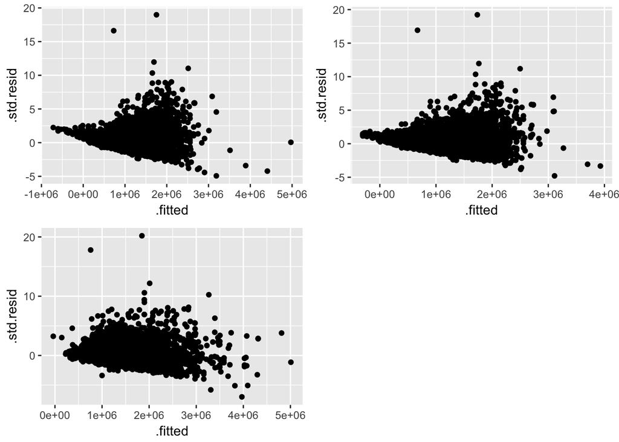

```r
grid.arrange(p1, p2, p3, ncol=2)
```